# Assignment 2

Author

Erin Yu

## Assignment 2

#Download data

```r
# Download the individual dataset
individual_data <- read.csv("https://raw.githubusercontent.com/USCbiostats/data-science-data/master/01_chs/chs_individual.csv")

# Download the regional dataset
regional_data <- read.csv("https://raw.githubusercontent.com/USCbiostats/data-science-data/master/01_chs/chs_regional.csv")
```

#Merge Data by Location

```r
combined_data <- merge(individual_data, regional_data, by = "townname")
```

#Check for duplicates

```r
nrow_combined <- nrow(combined_data)
combined_data <- combined_data[!duplicated(combined_data), ]
nrow_after <- nrow(combined_data)
```

#Handle missing values

```r
library(dplyr)
combined_data <- combined_data %>%
  group_by(male, hispanic) %>%
  mutate(across(where(is.numeric), ~ifelse(is.na(.), mean(., na.rm = TRUE), .))) %>%
  mutate(across(where(is.factor), ~ifelse(is.na(.), as.character(Mode(.)), .)))
```

#Create categorical variable named “obesity_level”

```r
combined_data <- combined_data %>%
  mutate(obesity_level = case_when(
    bmi < 14 ~ "underweight",
    bmi >= 14 & bmi <= 22 ~ "normal",
    bmi > 22 & bmi <= 24 ~ "overweight",
    bmi > 24 ~ "obese"
  ))
```

#Summary table of BMI

```r
summary_table <- combined_data %>%
  group_by(obesity_level) %>%
  summarize(min_bmi = min(bmi, na.rm = TRUE),
            max_BMI = max(bmi, na.rm = TRUE),
            total_obs = n())

print(summary_table)
```

```
# A tibble: 4 × 4
  obesity_level min_bmi max_BMI total_obs
  <chr>           <dbl>   <dbl>     <int>
1 normal           14.0    22.0       975
2 obese            24.0    41.3       103
3 overweight       22.0    24.0        87
4 underweight      11.3    14.0        35
```

#Create categorical variable “smoke_gas_exposure”

```r
combined_data <- combined_data %>%
  mutate(smoke_gas_exposure = case_when(
    smoke == 1 & gasstove == 1 ~ "Both",
    smoke == 1 & gasstove == 0 ~ "Smoke only",
    smoke == 0 & gasstove == 1 ~ "Gas only",
    TRUE ~ "Neither"
  ))
```

#Summary table of FEV by town

```r
summary_table_town <- combined_data %>%
  group_by(townname) %>%
  summarize(mean_fev = mean(fev, na.rm = TRUE), sd_fev = sd(fev, na.rm = TRUE))

print(summary_table_town)
```

```
# A tibble: 12 × 3
   townname      mean_fev sd_fev
   <chr>            <dbl>  <dbl>
 1 Alpine           2087.   291.
 2 Atascadero       2076.   324.
 3 Lake Elsinore    2039.   304.
 4 Lake Gregory     2085.   320.
 5 Lancaster        2003.   317.
 6 Lompoc           2034.   351.
 7 Long Beach       1986.   319.
 8 Mira Loma        1985.   325.
 9 Riverside        1990.   278.
10 San Dimas        2027.   319.
11 Santa Maria      2026.   312.
12 Upland           2024.   343.
```

#Summary table of FEV by sex

```r
summary_table_sex <- combined_data %>%
  group_by(male) %>%
  summarize(
    mean_fev = mean(fev, na.rm = TRUE),
    sd_fev = sd(fev, na.rm = TRUE),
    count = n()
  )


print(summary_table_sex)
```

```
# A tibble: 2 × 4
   male mean_fev sd_fev count
  <int>    <dbl>  <dbl> <int>
1     0    1959.   312.   610
2     1    2104.   308.   590
```

#Summary table of FEV by obesity level

```r
summary_table_obesity <- combined_data %>%
  group_by(obesity_level) %>%
  summarize(
    mean_fev = mean(fev, na.rm = TRUE),
    sd_FEV = sd(fev, na.rm = TRUE),
    count = n()
  )


print(summary_table_obesity)
```

```
# A tibble: 4 × 4
  obesity_level mean_fev sd_FEV count
  <chr>            <dbl>  <dbl> <int>
1 normal           2000.   295.   975
2 obese            2266.   325.   103
3 overweight       2224.   317.    87
4 underweight      1698.   303.    35
```

#Summary table of FEV by Smoke/Gas Exposure

```r
summary_table_smoke_gas <- combined_data %>%
  group_by(smoke_gas_exposure) %>%
  summarize(
    mean_fev = mean(fev, na.rm = TRUE),
    sd_FEV = sd(fev, na.rm = TRUE),
    count = n()
  )


print(summary_table_smoke_gas)
```

```
# A tibble: 4 × 4
  smoke_gas_exposure mean_fev sd_FEV count
  <chr>                 <dbl>  <dbl> <int>
1 Both                  2020.   299.   151
2 Gas only              2026.   318.   739
3 Neither               2044.   333.   274
4 Smoke only            2056.   296.    36
```

#EDA checklist:

#Read in data

#Check size of data

```r
dim(combined_data)
```

```
[1] 1200   51
```

There are 1200 observations and 51 variables

#Examine variables and type

```r
str(combined_data)
```

```
gropd_df [1,200 × 51] (S3: grouped_df/tbl_df/tbl/data.frame)
 $ townname          : chr [1:1200] "Alpine" "Alpine" "Alpine" "Alpine" ...
 $ sid               : int [1:1200] 841 835 838 840 865 867 842 839 844 847 ...
 $ male              : int [1:1200] 1 0 0 0 0 0 1 0 1 1 ...
 $ race              : chr [1:1200] "W" "W" "O" "W" ...
 $ hispanic          : int [1:1200] 1 0 1 0 0 1 1 1 1 0 ...
 $ agepft            : num [1:1200] 10.55 10.1 9.49 9.97 10.04 ...
 $ height            : num [1:1200] 150 143 133 146 162 141 139 142 143 137 ...
 $ weight            : num [1:1200] 78 69 62 78 140 94 65 86 65 69 ...
 $ bmi               : num [1:1200] 15.8 15.3 15.9 16.6 24.2 ...
 $ asthma            : num [1:1200] 0 0 0 0 1 ...
 $ active_asthma     : int [1:1200] 0 0 0 0 1 0 0 0 0 0 ...
 $ father_asthma     : num [1:1200] 0 0 0 0 0 ...
 $ mother_asthma     : num [1:1200] 0 0 0 0 0 ...
 $ wheeze            : num [1:1200] 0 0 0 0 1 ...
```

[output cut: 47 more lines]

```r
summary(combined_data[,c(9,21,24,51)])
```

```
      bmi             fev           pm25_mass      smoke_gas_exposure
 Min.   :11.30   Min.   : 984.8   Min.   : 5.960   Length:1200
 1st Qu.:15.96   1st Qu.:1827.6   1st Qu.: 7.615   Class :character
 Median :17.81   Median :2016.4   Median :10.545   Mode  :character
 Mean   :18.50   Mean   :2030.1   Mean   :14.362
 3rd Qu.:19.99   3rd Qu.:2223.6   3rd Qu.:20.988
 Max.   :41.27   Max.   :3323.7   Max.   :29.970
```

```r
combined_data <- combined_data[!is.na(combined_data$bmi) &
                               !is.na(combined_data$fev) &
                               !is.na(combined_data$pm25_mass) &
                               !is.na(combined_data$smoke_gas_exposure), ]
```

BMI and FEV are both numerical variables. Smoke and gas exposure is a character variable. PM2.5 exposure is numerical value

#Look at top and bottom of data

```r
head(combined_data)
```

```
# A tibble: 6 × 51
# Groups:   male, hispanic [3]
  townname   sid  male race  hispanic agepft height weight   bmi asthma
  <chr>    <int> <int> <chr>    <int>  <dbl>  <dbl>  <dbl> <dbl>  <dbl>
1 Alpine     841     1 W            1  10.5     150     78  15.8      0
2 Alpine     835     0 W            0  10.1     143     69  15.3      0
3 Alpine     838     0 O            1   9.49    133     62  15.9      0
4 Alpine     840     0 W            0   9.97    146     78  16.6      0
5 Alpine     865     0 W            0  10.0     162    140  24.2      1
6 Alpine     867     0 W            1   9.96    141     94  21.5      0
# ℹ 41 more variables: active_asthma <int>, father_asthma <dbl>,
#   mother_asthma <dbl>, wheeze <dbl>, hayfever <dbl>, allergy <dbl>,
#   educ_parent <dbl>, smoke <dbl>, pets <int>, gasstove <dbl>, fev <dbl>,
#   fvc <dbl>, mmef <dbl>, pm25_mass <dbl>, pm25_so4 <dbl>, pm25_no3 <dbl>,
#   pm25_nh4 <dbl>, pm25_oc <dbl>, pm25_ec <dbl>, pm25_om <dbl>, pm10_oc <dbl>,
#   pm10_ec <dbl>, pm10_tc <dbl>, formic <dbl>, acetic <dbl>, hcl <dbl>,
#   hno3 <dbl>, o3_max <dbl>, o3106 <dbl>, o3_24 <dbl>, no2 <dbl>, …
```

```r
tail(combined_data)
```

```
# A tibble: 6 × 51
# Groups:   male, hispanic [3]
  townname   sid  male race  hispanic agepft height weight   bmi asthma
  <chr>    <int> <int> <chr>    <int>  <dbl>  <dbl>  <dbl> <dbl>  <dbl>
1 Upland    1866     0 O            1   9.81   139    60    14.1      0
2 Upland    1867     0 M            1   9.62   140    71    16.5      0
3 Upland    2033     0 M            0  10.1    130    67    18.0      0
4 Upland    2031     1 W            0   9.80   135    83    20.7      0
5 Upland    2032     1 W            0   9.55   137    59    14.3      0
6 Upland    2053     0 W            0   9.85   139.   77.4  18.1      0
# ℹ 41 more variables: active_asthma <int>, father_asthma <dbl>,
#   mother_asthma <dbl>, wheeze <dbl>, hayfever <dbl>, allergy <dbl>,
#   educ_parent <dbl>, smoke <dbl>, pets <int>, gasstove <dbl>, fev <dbl>,
#   fvc <dbl>, mmef <dbl>, pm25_mass <dbl>, pm25_so4 <dbl>, pm25_no3 <dbl>,
#   pm25_nh4 <dbl>, pm25_oc <dbl>, pm25_ec <dbl>, pm25_om <dbl>, pm10_oc <dbl>,
#   pm10_ec <dbl>, pm10_tc <dbl>, formic <dbl>, acetic <dbl>, hcl <dbl>,
#   hno3 <dbl>, o3_max <dbl>, o3106 <dbl>, o3_24 <dbl>, no2 <dbl>, …
```

#Check your expectations I do not know what a normal FEV is supposed to be

#Validate with an external source According to the internet, normal FEV for males is supposed to be 3500-4500 mL, and 2500-3250 for females

#Formulate a question #What is the association between BMI and FEV?

```r
mod <- lm(fev ~ bmi, data = combined_data)
summary(mod)
```

```
Call:
lm(formula = fev ~ bmi, data = combined_data)

Residuals:
    Min      1Q  Median      3Q     Max
-989.47 -193.88  -11.32  179.43 1305.46

Coefficients:
            Estimate Std. Error t value Pr(>|t|)
(Intercept)  1452.46      44.49   32.65   <2e-16 ***
bmi            31.23       2.36   13.23   <2e-16 ***
---
Signif. codes:  0 '***' 0.001 '**' 0.01 '*' 0.05 '.' 0.1 ' ' 1

Residual standard error: 297.2 on 1198 degrees of freedom
Multiple R-squared:  0.1275,    Adjusted R-squared:  0.1268
F-statistic: 175.1 on 1 and 1198 DF,  p-value: < 2.2e-16
```

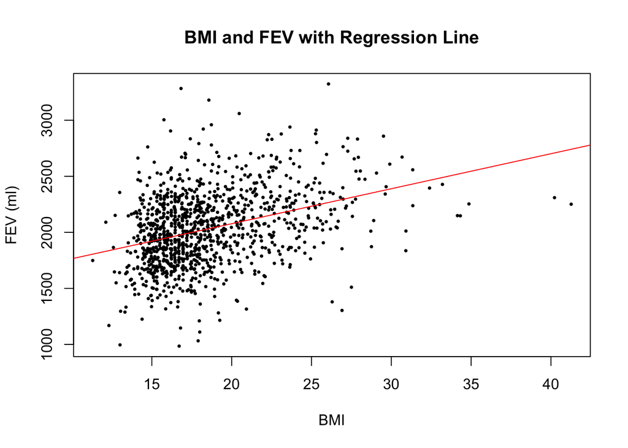

```r
plot(combined_data$bmi, combined_data$fev, pch = 16, cex = 0.5,
     main = "BMI and FEV with Regression Line", xlab = "BMI", ylab = "FEV (ml)")
abline(mod, col = "red")
```

```r
r_squared <- summary(mod)$r.squared
print(r_squared)
```

```
[1] 0.127529
```

There seems to be a positive relationship between BMI and FEV. The slope is 31.23 with a p-value that is less that .05. This means that for every increase in BMI, the FEV increases by 31.23 mL, which is a statistically significant increase.

#What is the association between smoke and gas exposure and FEV?

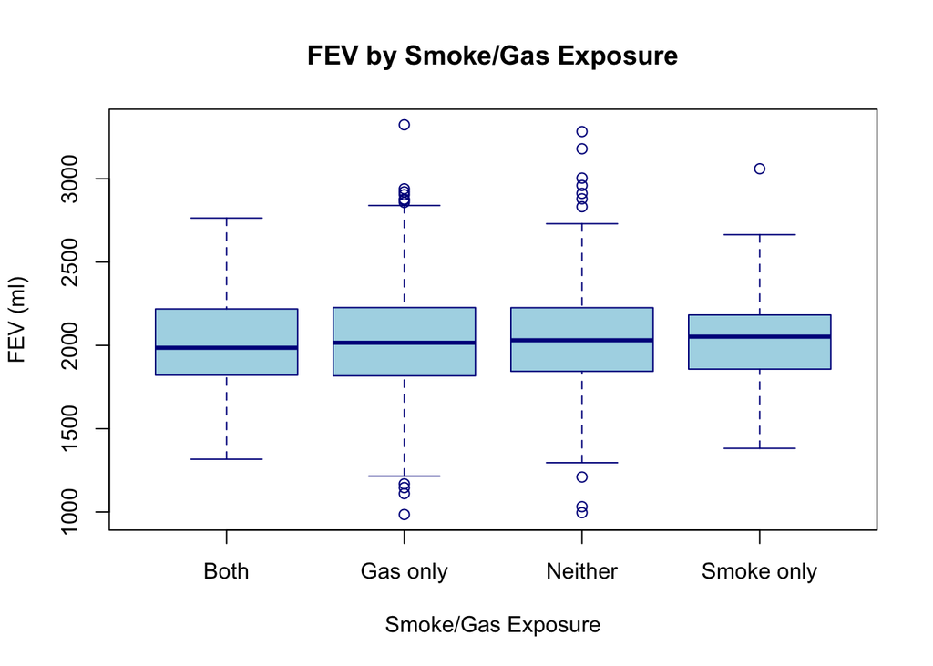

```r
boxplot(combined_data$fev ~ combined_data$smoke_gas_exposure,
        main = "FEV by Smoke/Gas Exposure",
        xlab = "Smoke/Gas Exposure",
        ylab = "FEV (ml)",
        col = "lightblue",
        border = "darkblue")
```

```r
mean_median_summary <- combined_data %>%
  group_by(smoke_gas_exposure) %>%
  summarise(
    mean_FEV = mean(`fev`, na.rm = TRUE),
    median_FEV = median(`fev`, na.rm = TRUE)
  )

# Display the summary table
print(mean_median_summary)
```

```
# A tibble: 4 × 3
  smoke_gas_exposure mean_FEV median_FEV
  <chr>                 <dbl>      <dbl>
1 Both                  2020.      1986.
2 Gas only              2026.      2016.
3 Neither               2044.      2031.
4 Smoke only            2056.      2052.
```

#What is the association between PM2.5 exposure and FEV?

```r
lm_pm25_model <- lm(`fev` ~ pm25_mass, data = combined_data)


summary(lm_pm25_model)
```

```
Call:
lm(formula = fev ~ pm25_mass, data = combined_data)

Residuals:
     Min       1Q   Median       3Q      Max
-1070.63  -206.57   -13.33   195.87  1277.65

Coefficients:
            Estimate Std. Error t value Pr(>|t|)
(Intercept) 2073.452     19.309 107.383   <2e-16 ***
pm25_mass     -3.016      1.184  -2.548    0.011 *
---
Signif. codes:  0 '***' 0.001 '**' 0.01 '*' 0.05 '.' 0.1 ' ' 1

Residual standard error: 317.3 on 1198 degrees of freedom
Multiple R-squared:  0.005389,  Adjusted R-squared:  0.004559
F-statistic: 6.492 on 1 and 1198 DF,  p-value: 0.01096
```

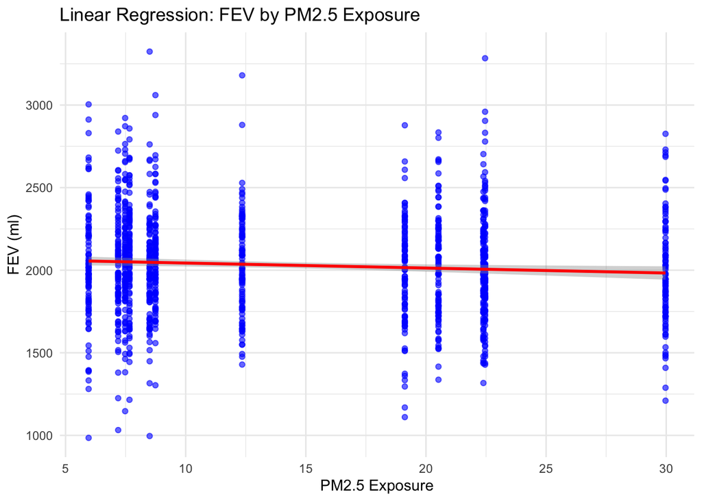

```r
library(ggplot2)


lm_pm25_model <- lm(`fev` ~ pm25_mass, data = combined_data)


ggplot(combined_data, aes(x = pm25_mass, y = `fev`)) +
  geom_point(color = "blue", alpha = 0.6) +
  geom_smooth(method = "lm", color = "red") +
  labs(
    title = "Linear Regression: FEV by PM2.5 Exposure",
    x = "PM2.5 Exposure",
    y = "FEV (ml)"
  ) +
  theme_minimal()
```

It seems that as PM2.5 exposure increases, FEV decreases. The linear regression shows a slope of -3.016 with a p-value of 0.011. This means that with every increase in a unit of pm25 mass, the FEV decreases by 3.016 mL, which was statistically significant.

#Visualization

#Facet plot showing scatterplots with regression lines of BMI vs FEV by “townname”

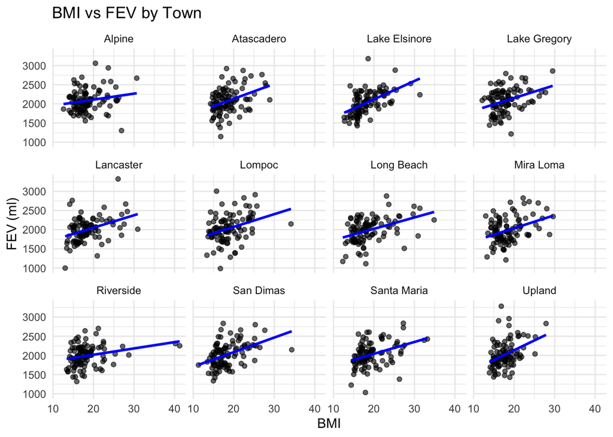

```r
library(ggplot2)

ggplot(combined_data, aes(x = bmi, y = fev)) +
  geom_point(alpha = 0.6) +
  geom_smooth(method = "lm", se = FALSE, color = "blue") +
  facet_wrap(~ townname) +
  labs(
    title = "BMI vs FEV by Town",
    x = "BMI",
    y = "FEV (ml)"
  ) +
  theme_minimal()
```

#Stacked histograms of FEV by BMI category

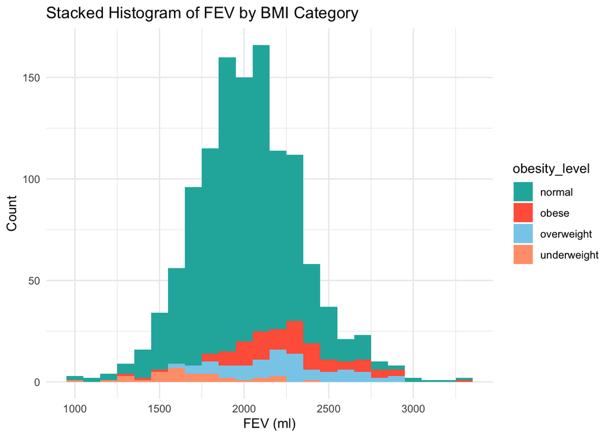

```r
library(ggplot2)
ggplot(combined_data, aes(x = fev, fill = obesity_level)) +
  geom_histogram(position = "stack", binwidth = 100) +
  labs(
    title = "Stacked Histogram of FEV by BMI Category",
    x = "FEV (ml)",
    y = "Count"
  ) +
  scale_fill_manual(values = c("underweight" = "#FFA07A", "normal" = "#20B2AA", "overweight" = "#87CEEB", "obese" = "#FF6347")) +
  theme_minimal()
```

#Stacked histogram of FEV by Smoke/Gas Exposure

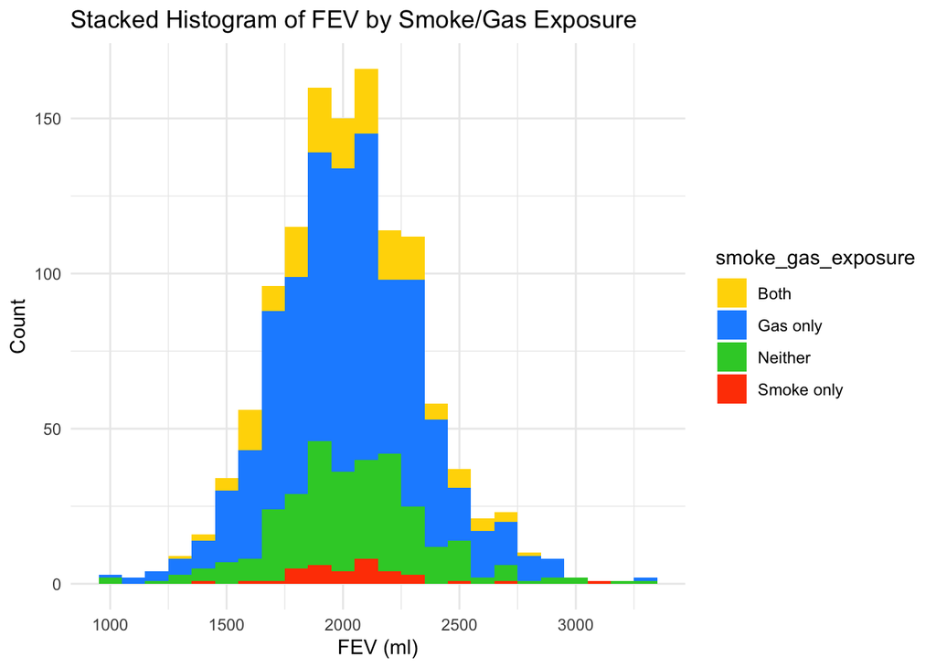

```r
ggplot(combined_data, aes(x = fev, fill = smoke_gas_exposure)) +
  geom_histogram(position = "stack", binwidth = 100) +
  labs(
    title = "Stacked Histogram of FEV by Smoke/Gas Exposure",
    x = "FEV (ml)",
    y = "Count"
  ) +
  scale_fill_manual(values = c("Both" = "#FFD700", "Smoke only" = "#FF4500", "Gas only" = "#1E90FF", "Neither" = "#32CD32")) +
  theme_minimal()
```

#Barchart of BMI by smoke/gas exposure

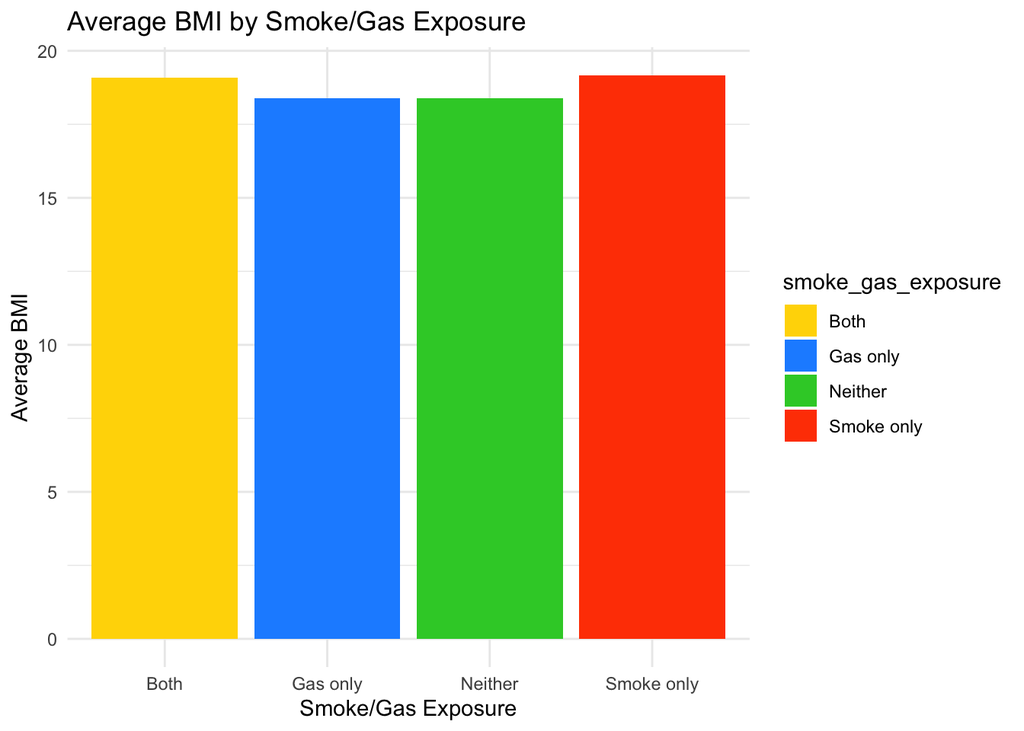

```r
ggplot(combined_data, aes(x = smoke_gas_exposure, y = bmi, fill = smoke_gas_exposure)) +
  geom_bar(stat = "summary", fun = "mean") +
  labs(
    title = "Average BMI by Smoke/Gas Exposure",
    x = "Smoke/Gas Exposure",
    y = "Average BMI"
  ) +
  scale_fill_manual(values = c("Both" = "#FFD700", "Smoke only" = "#FF4500", "Gas only" = "#1E90FF", "Neither" = "#32CD32")) +
  theme_minimal()
```

#Statistical Summary Graphs of FEV by BMI

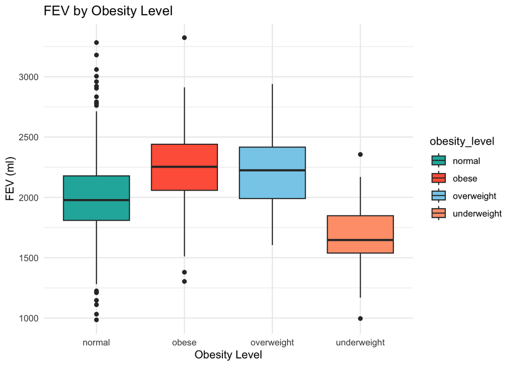

```r
ggplot(combined_data, aes(x = obesity_level, y = fev, fill = obesity_level)) +
  geom_boxplot() +
  labs(
    title = "FEV by Obesity Level",
    x = "Obesity Level",
    y = "FEV (ml)"
  ) +
  scale_fill_manual(values = c("underweight" = "#FFA07A", "normal" = "#20B2AA", "overweight" = "#87CEEB", "obese" = "#FF6347")) +
  theme_minimal()
```

#Statistical Summary Graphs of FEV by Smoke/Gas Exposure

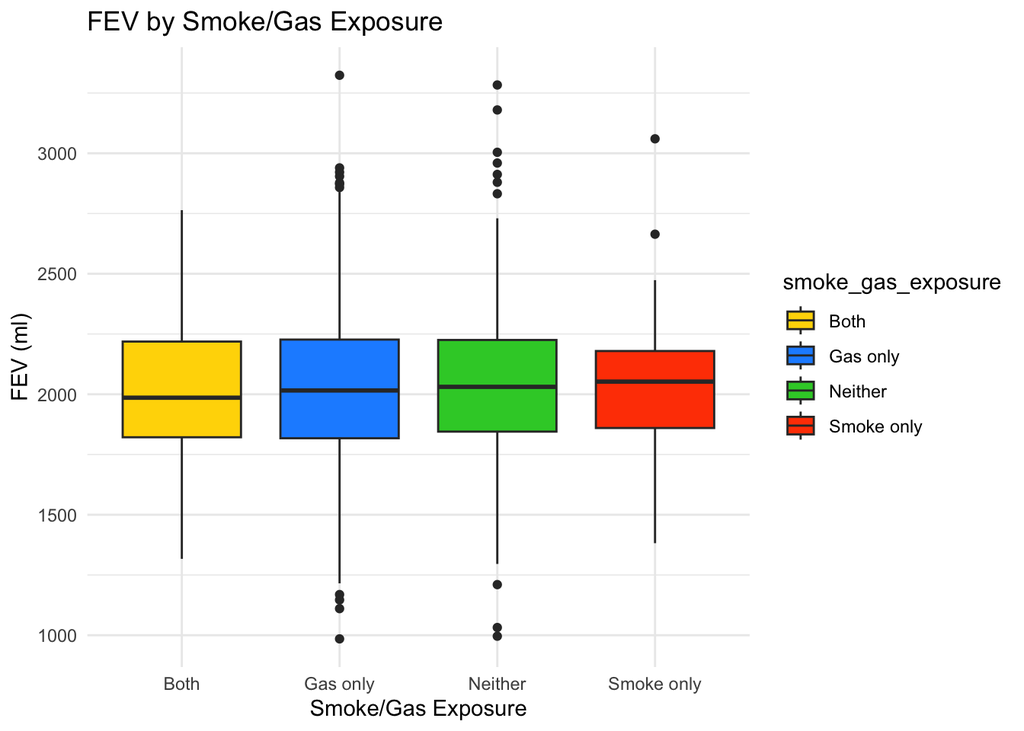

```r
ggplot(combined_data, aes(x = smoke_gas_exposure, y = fev, fill = smoke_gas_exposure)) +
  geom_boxplot() +
  labs(
    title = "FEV by Smoke/Gas Exposure",
    x = "Smoke/Gas Exposure",
    y = "FEV (ml)"
  ) +
  scale_fill_manual(values = c("Both" = "#FFD700", "Smoke only" = "#FF4500", "Gas only" = "#1E90FF", "Neither" = "#32CD32")) +
  theme_minimal()
```

#Leaflet showing PM2.5 concentrations

```r
library(leaflet)

leaflet(combined_data) %>%
  addTiles() %>%
  addCircleMarkers(
    lng = ~lon,
    lat = ~lat,
    radius = ~pm25_mass * 0.2,
    color = ~ifelse(pm25_mass > 12, "red", "green"),
    popup = ~paste("Town: ", townname, "<br>", "PM2.5: ", pm25_mass, " µg/m³")
  ) %>%
  addLegend("bottomright", pal = colorNumeric("YlOrRd", combined_data$pm25_mass),
            values = combined_data$pm25_mass,
            title = "PM2.5 Concentration (µg/m³)")
```

[interactive chart not shown]

#Visualization to examine whether PM2.5 is associated with FEV

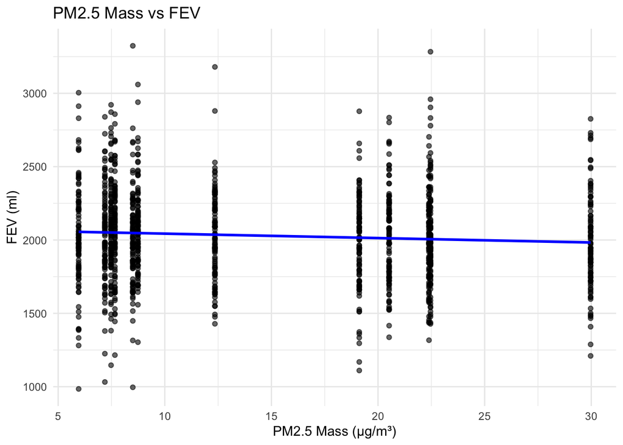

```r
ggplot(combined_data, aes(x = pm25_mass, y = fev)) +
  geom_point(alpha = 0.6) +
  geom_smooth(method = "lm", se = FALSE, color = "blue") +
  labs(
    title = "PM2.5 Mass vs FEV",
    x = "PM2.5 Mass (µg/m³)",
    y = "FEV (ml)"
  ) +
  theme_minimal()
```